# Real-world Data Wrangling

```python
!python -m pip install kaggle==1.6.12
```

[output not shown]

```python
!pip install --target=/workspace ucimlrepo numpy==1.24.3
```

[output not shown]

## 1. Gather data

In this section, I will extract data using two different data gathering methods and combine the data.

### **1.1.** Problem Statement

In this project, I will analyze and study the relationship between movie’s rating and revenues at the global box office, as I will use two interconnected datasets with a close relationship between them, the first is IMDB Movies Dataset and the second is All time worldwide box office collection. I will also clean the dataset and merge the data to clearly analyze the relationship between the rating and revenues.

### **1.2.** Gather at least two datasets using two different data gathering methods

#### **Dataset 1:IMDB Movies Dataset**

Type: CSV File

Method: I manually downloaded the data from Kaggle. This dataset contains comprehensive information about movies from IMDB, which will be important for analyzing the relationship between a movie and its revenue. Dataset variables:

- Poster_Link:Poster Link of Movie
- Series_Title:Name of the Movie
- Released_Year:Released Year of the Movie
- Certificate:Certificate of the Movie
- Runtime:Total Runtime of the Movie
- Genre:Genre of the Movie
- IMDB_Rating:IMBD Rating of the Movie
- Overview:Overview of the Movie
- Meta_score:Metascore earned by the Movie
- Director:Name of the Director
- Star1:Name of the Star1
- Star2:Name of the Star2
- Star3:Name of the Star3
- Star4:Name of the Star4
- No_of_Votes:Total number of votes
- Gross:Gross

This dataset was selected because it contains the columns and information that will be useful in my chosen analysis. Its source, IMDB, is a reliable and globally renowned source, which enhances the credibility of the analysis and the public's interest in it, especially for movie lovers and those interested in the film industry.

```python
import pandas as pd

df_imdb = pd.read_csv('imdb_top_1000.csv')
df_imdb.head()
```

|  | Poster_Link | Series_Title | Released_Year | Certificate | Runtime | Genre | IMDB_Rating | Overview | Meta_score | Director | Star1 | Star2 | Star3 | Star4 | No_of_Votes | Gross |
| --- | --- | --- | --- | --- | --- | --- | --- | --- | --- | --- | --- | --- | --- | --- | --- | --- |
| 0 | https://m.media-amazon.com/images/M/MV5BMDFkYT... | The Shawshank Redemption | 1994 | A | 142 min | Drama | 9.3 | Two imprisoned men bond over a number of years... | 80.0 | Frank Darabont | Tim Robbins | Morgan Freeman | Bob Gunton | William Sadler | 2343110 | 28,341,469 |
| 1 | https://m.media-amazon.com/images/M/MV5BM2MyNj... | The Godfather | 1972 | A | 175 min | Crime, Drama | 9.2 | An organized crime dynasty's aging patriarch t... | 100.0 | Francis Ford Coppola | Marlon Brando | Al Pacino | James Caan | Diane Keaton | 1620367 | 134,966,411 |
| 2 | https://m.media-amazon.com/images/M/MV5BMTMxNT... | The Dark Knight | 2008 | UA | 152 min | Action, Crime, Drama | 9.0 | When the menace known as the Joker wreaks havo... | 84.0 | Christopher Nolan | Christian Bale | Heath Ledger | Aaron Eckhart | Michael Caine | 2303232 | 534,858,444 |
| 3 | https://m.media-amazon.com/images/M/MV5BMWMwMG... | The Godfather: Part II | 1974 | A | 202 min | Crime, Drama | 9.0 | The early life and career of Vito Corleone in ... | 90.0 | Francis Ford Coppola | Al Pacino | Robert De Niro | Robert Duvall | Diane Keaton | 1129952 | 57,300,000 |
| 4 | https://m.media-amazon.com/images/M/MV5BMWU4N2... | 12 Angry Men | 1957 | U | 96 min | Crime, Drama | 9.0 | A jury holdout attempts to prevent a miscarria... | 96.0 | Sidney Lumet | Henry Fonda | Lee J. Cobb | Martin Balsam | John Fiedler | 689845 | 4,360,000 |

#### Dataset 2

Type: CSV File

Method: Programmatically downloading files

Dataset variables:

- Title:Title of the movie
- Worldwide :Worldwide box office collection
- Domestic:Domestic box office collection
- Domestic_percent: Percentage of domestic box office collection
- Foreign :Foreign box office collection
- Foreign_percent:Percentage of foreign box office collection

The reason I chose this dataset was because it contains accurate data on box office receipts and covers a sufficiently long period of time to analyze clear and recent trends in the world of cinema. It also complements the original IMDB dataset, as combining them helps analyze the relationship between audience or critics' ratings and a film's financial performance.

```python
pip install kagglehub
```

```
     ━━━━━━━━━━━━━━━━━━━━━━━━━━━━━━━━━━━━━━━━ 63.4/63.4 kB 1.2 MB/s eta 0:00:00a 0:00:01
```

```python
import kagglehub

# Download latest version
path = kagglehub.dataset_download("somnath2/box-office")

print("Path to dataset files:", path)
```

```
Downloading from https://www.kaggle.com/api/v1/datasets/download/somnath2/box-office?dataset_version_number=1...
```

```
Extracting files...
Path to dataset files: /home/student/.cache/kagglehub/datasets/somnath2/box-office/versions/1
```

```python
import os
downloaded_files = os.listdir(path)
print("Files in the dataset:", downloaded_files)
```

```
Files in the dataset: ['box office.csv']
```

```python
import pandas as pd


file_path = "/home/student/.cache/kagglehub/datasets/somnath2/box-office/versions/1/box office.csv"

data = pd.read_csv(file_path)

data.head()
```

|  | Title | Worldwide | Domestic | Domestic_percent | Foreign | Foreign_percent |
| --- | --- | --- | --- | --- | --- | --- |
| 0 | Avengers: Endgame | $2,797,501,328 | $858,373,000 | 30.70% | $1,939,128,328 | 69.30% |
| 1 | Star Wars: Episode VII - The Force Awakens | $2,068,223,624 | $936,662,225 | 45.30% | $1,131,561,399 | 54.70% |
| 2 | Avengers: Infinity War | $2,048,359,754 | $678,815,482 | 33.10% | $1,369,544,272 | 66.90% |
| 3 | Spider-Man: No Way Home | $1,906,693,477 | $804,793,477 | 42.20% | $1,101,900,000 | 57.80% |
| 4 | Jurassic World | $1,670,400,637 | $652,270,625 | 39% | $1,018,130,012 | 61% |

## 2. Assess data

### Quality Issue 1:

Checking for missing values in the first dataset

```python
missing = df_imdb.isnull().sum()
print(missing)
```

```
Poster_Link        0
Series_Title       0
Released_Year      0
Certificate      101
Runtime            0
Genre              0
IMDB_Rating        0
Overview           0
Meta_score       157
Director           0
Star1              0
Star2              0
Star3              0
Star4              0
No_of_Votes        0
Gross            169
dtype: int64
```

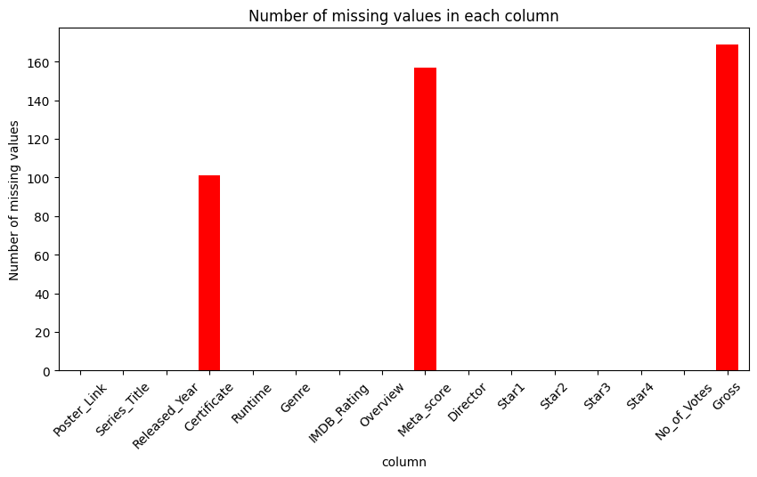

```python
import matplotlib.pyplot as plt

plt.figure(figsize=(10, 5))
missing.plot(kind='bar', color='red')
plt.title("Number of missing values in each column")
plt.xlabel("column")
plt.ylabel("Number of missing values")
plt.xticks(rotation=45)
plt.show()
```

When examining the missing values in this data, we will find that some columns contain missing values that could affect the accuracy and completeness of the analysis if not processed properly. The results and graphs show the columns containing missing values and their number, which will be processed later.

Checking for missing values in the second dataset

```python
missing = data.isnull().sum()
print (missing)
```

```
Title               0
Worldwide           0
Domestic            0
Domestic_percent    0
Foreign             0
Foreign_percent     0
dtype: int64
```

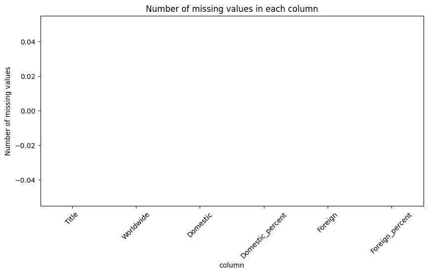

```python
plt.figure(figsize=(10, 5))
missing.plot(kind='bar', color='red')
plt.title("Number of missing values in each column")
plt.xlabel("column")
plt.ylabel("Number of missing values")
plt.xticks(rotation=45)
plt.show()
```

Issue and justification: In the second data set, we find that all columns are complete and do not contain any missing values.

### Quality Issue 2:

Show some information about the first dataset to check the types of data for columns

```python
df_imdb.info()
```

```
<class 'pandas.core.frame.DataFrame'>
RangeIndex: 1000 entries, 0 to 999
Data columns (total 16 columns):
 #   Column         Non-Null Count  Dtype
---  ------         --------------  -----
 0   Poster_Link    1000 non-null   object
 1   Series_Title   1000 non-null   object
 2   Released_Year  1000 non-null   object
 3   Certificate    899 non-null    object
 4   Runtime        1000 non-null   object
 5   Genre          1000 non-null   object
 6   IMDB_Rating    1000 non-null   float64
 7   Overview       1000 non-null   object
 8   Meta_score     843 non-null    float64
 9   Director       1000 non-null   object
 10  Star1          1000 non-null   object
 11  Star2          1000 non-null   object
 12  Star3          1000 non-null   object
 13  Star4          1000 non-null   object
 14  No_of_Votes    1000 non-null   int64
 15  Gross          831 non-null    object
dtypes: float64(2), int64(1), object(13)
memory usage: 125.1+ KB
```

Through the previous result after examining the data types in this dataset, it became clear to me that there are several columns that contain inappropriate data types and need to be modified to obtain accuracy suitable for the analysis. Among these columns were: Released_Year, Runtime, Gross, which were considered objects, and it is better to be a suitable type for the nature of the data in these columns, which will be processed later.

Show some information about the second dataset to check the types of data for columns

```python
data.info()
```

```
<class 'pandas.core.frame.DataFrame'>
RangeIndex: 2600 entries, 0 to 2599
Data columns (total 6 columns):
 #   Column            Non-Null Count  Dtype
---  ------            --------------  -----
 0   Title             2600 non-null   object
 1   Worldwide         2600 non-null   object
 2   Domestic          2600 non-null   object
 3   Domestic_percent  2600 non-null   object
 4   Foreign           2600 non-null   object
 5   Foreign_percent   2600 non-null   object
dtypes: object(6)
memory usage: 122.0+ KB
```

Also in this dataset, it became clear to me that there are several columns that contain inappropriate data types and need to be modified to obtain accuracy suitable for the analysis. Among these columns were: Worldwide, Foreign, Foreign_percent, Domestic, Domestic_percent, which were considered objects because they contain symbols that will be processed later because it is better for them to be of a type suitable for the nature of the data.

### Tidiness Issue 1:

Display the first 10 rows in the first dataset to search for the presence of Tidiness Issue

```python
df_imdb.head(10)
```

|  | Poster_Link | Series_Title | Released_Year | Certificate | Runtime | Genre | IMDB_Rating | Overview | Meta_score | Director | Star1 | Star2 | Star3 | Star4 | No_of_Votes | Gross |
| --- | --- | --- | --- | --- | --- | --- | --- | --- | --- | --- | --- | --- | --- | --- | --- | --- |
| 0 | https://m.media-amazon.com/images/M/MV5BMDFkYT... | The Shawshank Redemption | 1994 | A | 142 min | Drama | 9.3 | Two imprisoned men bond over a number of years... | 80.0 | Frank Darabont | Tim Robbins | Morgan Freeman | Bob Gunton | William Sadler | 2343110 | 28,341,469 |
| 1 | https://m.media-amazon.com/images/M/MV5BM2MyNj... | The Godfather | 1972 | A | 175 min | Crime, Drama | 9.2 | An organized crime dynasty's aging patriarch t... | 100.0 | Francis Ford Coppola | Marlon Brando | Al Pacino | James Caan | Diane Keaton | 1620367 | 134,966,411 |
| 2 | https://m.media-amazon.com/images/M/MV5BMTMxNT... | The Dark Knight | 2008 | UA | 152 min | Action, Crime, Drama | 9.0 | When the menace known as the Joker wreaks havo... | 84.0 | Christopher Nolan | Christian Bale | Heath Ledger | Aaron Eckhart | Michael Caine | 2303232 | 534,858,444 |
| 3 | https://m.media-amazon.com/images/M/MV5BMWMwMG... | The Godfather: Part II | 1974 | A | 202 min | Crime, Drama | 9.0 | The early life and career of Vito Corleone in ... | 90.0 | Francis Ford Coppola | Al Pacino | Robert De Niro | Robert Duvall | Diane Keaton | 1129952 | 57,300,000 |
| 4 | https://m.media-amazon.com/images/M/MV5BMWU4N2... | 12 Angry Men | 1957 | U | 96 min | Crime, Drama | 9.0 | A jury holdout attempts to prevent a miscarria... | 96.0 | Sidney Lumet | Henry Fonda | Lee J. Cobb | Martin Balsam | John Fiedler | 689845 | 4,360,000 |
| 5 | https://m.media-amazon.com/images/M/MV5BNzA5ZD... | The Lord of the Rings: The Return of the King | 2003 | U | 201 min | Action, Adventure, Drama | 8.9 | Gandalf and Aragorn lead the World of Men agai... | 94.0 | Peter Jackson | Elijah Wood | Viggo Mortensen | Ian McKellen | Orlando Bloom | 1642758 | 377,845,905 |
| 6 | https://m.media-amazon.com/images/M/MV5BNGNhMD... | Pulp Fiction | 1994 | A | 154 min | Crime, Drama | 8.9 | The lives of two mob hitmen, a boxer, a gangst... | 94.0 | Quentin Tarantino | John Travolta | Uma Thurman | Samuel L. Jackson | Bruce Willis | 1826188 | 107,928,762 |
| 7 | https://m.media-amazon.com/images/M/MV5BNDE4OT... | Schindler's List | 1993 | A | 195 min | Biography, Drama, History | 8.9 | In German-occupied Poland during World War II,... | 94.0 | Steven Spielberg | Liam Neeson | Ralph Fiennes | Ben Kingsley | Caroline Goodall | 1213505 | 96,898,818 |
| 8 | https://m.media-amazon.com/images/M/MV5BMjAxMz... | Inception | 2010 | UA | 148 min | Action, Adventure, Sci-Fi | 8.8 | A thief who steals corporate secrets through t... | 74.0 | Christopher Nolan | Leonardo DiCaprio | Joseph Gordon-Levitt | Elliot Page | Ken Watanabe | 2067042 | 292,576,195 |
| 9 | https://m.media-amazon.com/images/M/MV5BMmEzNT... | Fight Club | 1999 | A | 139 min | Drama | 8.8 | An insomniac office worker and a devil-may-car... | 66.0 | David Fincher | Brad Pitt | Edward Norton | Meat Loaf | Zach Grenier | 1854740 | 37,030,102 |

Upon inspection, we see that this dataset contains two columns with a Tidiness Issue, which is the presence of symbols such as a comma in the gross column and (min) in the runtime column. This causes them to be considered an object, which hinders calculations or graphs on this column. The average cannot be calculated, values cannot be compared, or even visually represented unless they are converted to an integer format.

Display the first 10 rows in the second dataset to search for the presence of Tidiness Issue.

```python
data.head(10)
```

|  | Title | Worldwide | Domestic | Domestic_percent | Foreign | Foreign_percent |
| --- | --- | --- | --- | --- | --- | --- |
| 0 | Avengers: Endgame | $2,797,501,328 | $858,373,000 | 30.70% | $1,939,128,328 | 69.30% |
| 1 | Star Wars: Episode VII - The Force Awakens | $2,068,223,624 | $936,662,225 | 45.30% | $1,131,561,399 | 54.70% |
| 2 | Avengers: Infinity War | $2,048,359,754 | $678,815,482 | 33.10% | $1,369,544,272 | 66.90% |
| 3 | Spider-Man: No Way Home | $1,906,693,477 | $804,793,477 | 42.20% | $1,101,900,000 | 57.80% |
| 4 | Jurassic World | $1,670,400,637 | $652,270,625 | 39% | $1,018,130,012 | 61% |
| 5 | The Lion King | $1,656,943,394 | $543,638,043 | 32.80% | $1,113,305,351 | 67.20% |
| 6 | The Avengers | $1,518,812,988 | $623,357,910 | 41% | $895,455,078 | 59% |
| 7 | Furious 7 | $1,515,047,671 | $353,007,020 | 23.30% | $1,162,040,651 | 76.70% |
| 8 | Top Gun: Maverick | $1,488,732,821 | $718,732,821 | 48.30% | $770,000,000 | 51.70% |
| 9 | Frozen II | $1,450,026,933 | $477,373,578 | 32.90% | $972,653,355 | 67.10% |

Issue and justification: This dataset also contains a Tidiness Issue, as in the first group. We see from the results that the columns Domestic, Worldwide, Foreign, and Foreign_percent contain the $ and % signs, which also cause them to be considered objects. They should be either Integr or Float.

### Tidiness Issue 2:

Genre column contains more than one value in the same cell

```python
df_imdb.head(10)
```

|  | Poster_Link | Series_Title | Released_Year | Certificate | Runtime | Genre | IMDB_Rating | Overview | Meta_score | Director | Star1 | Star2 | Star3 | Star4 | No_of_Votes | Gross |
| --- | --- | --- | --- | --- | --- | --- | --- | --- | --- | --- | --- | --- | --- | --- | --- | --- |
| 0 | https://m.media-amazon.com/images/M/MV5BMDFkYT... | The Shawshank Redemption | 1994 | A | 142 min | Drama | 9.3 | Two imprisoned men bond over a number of years... | 80.0 | Frank Darabont | Tim Robbins | Morgan Freeman | Bob Gunton | William Sadler | 2343110 | 28,341,469 |
| 1 | https://m.media-amazon.com/images/M/MV5BM2MyNj... | The Godfather | 1972 | A | 175 min | Crime, Drama | 9.2 | An organized crime dynasty's aging patriarch t... | 100.0 | Francis Ford Coppola | Marlon Brando | Al Pacino | James Caan | Diane Keaton | 1620367 | 134,966,411 |
| 2 | https://m.media-amazon.com/images/M/MV5BMTMxNT... | The Dark Knight | 2008 | UA | 152 min | Action, Crime, Drama | 9.0 | When the menace known as the Joker wreaks havo... | 84.0 | Christopher Nolan | Christian Bale | Heath Ledger | Aaron Eckhart | Michael Caine | 2303232 | 534,858,444 |
| 3 | https://m.media-amazon.com/images/M/MV5BMWMwMG... | The Godfather: Part II | 1974 | A | 202 min | Crime, Drama | 9.0 | The early life and career of Vito Corleone in ... | 90.0 | Francis Ford Coppola | Al Pacino | Robert De Niro | Robert Duvall | Diane Keaton | 1129952 | 57,300,000 |
| 4 | https://m.media-amazon.com/images/M/MV5BMWU4N2... | 12 Angry Men | 1957 | U | 96 min | Crime, Drama | 9.0 | A jury holdout attempts to prevent a miscarria... | 96.0 | Sidney Lumet | Henry Fonda | Lee J. Cobb | Martin Balsam | John Fiedler | 689845 | 4,360,000 |
| 5 | https://m.media-amazon.com/images/M/MV5BNzA5ZD... | The Lord of the Rings: The Return of the King | 2003 | U | 201 min | Action, Adventure, Drama | 8.9 | Gandalf and Aragorn lead the World of Men agai... | 94.0 | Peter Jackson | Elijah Wood | Viggo Mortensen | Ian McKellen | Orlando Bloom | 1642758 | 377,845,905 |
| 6 | https://m.media-amazon.com/images/M/MV5BNGNhMD... | Pulp Fiction | 1994 | A | 154 min | Crime, Drama | 8.9 | The lives of two mob hitmen, a boxer, a gangst... | 94.0 | Quentin Tarantino | John Travolta | Uma Thurman | Samuel L. Jackson | Bruce Willis | 1826188 | 107,928,762 |
| 7 | https://m.media-amazon.com/images/M/MV5BNDE4OT... | Schindler's List | 1993 | A | 195 min | Biography, Drama, History | 8.9 | In German-occupied Poland during World War II,... | 94.0 | Steven Spielberg | Liam Neeson | Ralph Fiennes | Ben Kingsley | Caroline Goodall | 1213505 | 96,898,818 |
| 8 | https://m.media-amazon.com/images/M/MV5BMjAxMz... | Inception | 2010 | UA | 148 min | Action, Adventure, Sci-Fi | 8.8 | A thief who steals corporate secrets through t... | 74.0 | Christopher Nolan | Leonardo DiCaprio | Joseph Gordon-Levitt | Elliot Page | Ken Watanabe | 2067042 | 292,576,195 |
| 9 | https://m.media-amazon.com/images/M/MV5BMmEzNT... | Fight Club | 1999 | A | 139 min | Drama | 8.8 | An insomniac office worker and a devil-may-car... | 66.0 | David Fincher | Brad Pitt | Edward Norton | Meat Loaf | Zach Grenier | 1854740 | 37,030,102 |

Issue and justification: We find that the Genre column contains more than one value in the same cell, and this is not permissible because each cell in the table is supposed to contain only one value for each variable.

## 3. Clean data

Create a copy of all the data before cleaning.

```python
df_imdb_copy = df_imdb.copy()
data_copy = data.copy()
df_imdb_copy.to_csv('raw_df_imdb.csv', index=False)
data_copy.to_csv('raw_box-office.csv', index=False)
```

### **Tidiness Issue 1:**

for dataset 1

```python
# Cleaning the 'Gross' column
df_imdb['Gross'] = df_imdb['Gross'].replace({',': ''}, regex=True)  # Remove commas from the 'Gross' column
df_imdb['Gross'] = pd.to_numeric(df_imdb['Gross'], errors='coerce')  # Convert the values to numeric (integers), invalid entries become NaN

# Cleaning the 'Runtime' column
df_imdb['Runtime'] = df_imdb['Runtime'].replace({' min': '', 'hr': ''}, regex=True)  # Remove the word 'min' and 'hr' from the 'Runtime' column
df_imdb['Runtime'] = pd.to_numeric(df_imdb['Runtime'], errors='coerce')  # Convert the values to numeric (integers), invalid entries become NaN
```

```python
# Check the cleaned columns
print(df_imdb[['Gross', 'Runtime']].head())
```

```
         Gross  Runtime
0   28341469.0      142
1  134966411.0      175
2  534858444.0      152
3   57300000.0      202
4    4360000.0       96
```

Justification: I cleaned up the "Gross" and "Runtime" columns in the dataset. In the "Gross" column, I removed commas to convert the values to integers using replace() and pd.to_numeric(). In the "Runtime" column, I removed strings like "min" and "hr" to convert the values to numbers as well using the same method.

for dataset2

```python
# Cleaning the 'Worldwide', 'Domestic', and 'Foreign' columns by removing the '$' symbol
data['Worldwide'] = data['Worldwide'].replace({'\$': '', ',': ''}, regex=True)
data['Domestic'] = data['Domestic'].replace({'\$': '', ',': ''}, regex=True)
data['Foreign'] = data['Foreign'].replace({'\$': '', ',': ''}, regex=True)

# Cleaning the 'Domestic_percent' and 'Foreign_percent' columns by removing the '%' symbol
data['Domestic_percent'] = data['Domestic_percent'].replace({'%': ''}, regex=True)
data['Foreign_percent'] = data['Foreign_percent'].replace({'%': ''}, regex=True)
```

```python
print(data[['Worldwide', 'Domestic', 'Foreign', 'Domestic_percent', 'Foreign_percent']].head())
```

```
    Worldwide   Domestic     Foreign Domestic_percent Foreign_percent
0  2797501328  858373000  1939128328            30.70           69.30
1  2068223624  936662225  1131561399            45.30           54.70
2  2048359754  678815482  1369544272            33.10           66.90
3  1906693477  804793477  1101900000            42.20           57.80
4  1670400637  652270625  1018130012               39              61
```

### **Tidiness Issue 2:**

```python
# Split the genres and expand the rows
df_imdb['Genre'] = df_imdb['Genre'].apply(lambda x: [g.strip() for g in x.split(',')])
df_imdb = df_imdb.explode('Genre').reset_index(drop=True)
```

```python
df_imdb.head(10)
```

|  | Poster_Link | Series_Title | Released_Year | Certificate | Runtime | Genre | IMDB_Rating | Overview | Meta_score | Director | Star1 | Star2 | Star3 | Star4 | No_of_Votes | Gross |
| --- | --- | --- | --- | --- | --- | --- | --- | --- | --- | --- | --- | --- | --- | --- | --- | --- |
| 0 | https://m.media-amazon.com/images/M/MV5BMDFkYT... | The Shawshank Redemption | 1994 | A | 142 | Drama | 9.3 | Two imprisoned men bond over a number of years... | 80.0 | Frank Darabont | Tim Robbins | Morgan Freeman | Bob Gunton | William Sadler | 2343110 | 28341469.0 |
| 1 | https://m.media-amazon.com/images/M/MV5BM2MyNj... | The Godfather | 1972 | A | 175 | Crime | 9.2 | An organized crime dynasty's aging patriarch t... | 100.0 | Francis Ford Coppola | Marlon Brando | Al Pacino | James Caan | Diane Keaton | 1620367 | 134966411.0 |
| 2 | https://m.media-amazon.com/images/M/MV5BM2MyNj... | The Godfather | 1972 | A | 175 | Drama | 9.2 | An organized crime dynasty's aging patriarch t... | 100.0 | Francis Ford Coppola | Marlon Brando | Al Pacino | James Caan | Diane Keaton | 1620367 | 134966411.0 |
| 3 | https://m.media-amazon.com/images/M/MV5BMTMxNT... | The Dark Knight | 2008 | UA | 152 | Action | 9.0 | When the menace known as the Joker wreaks havo... | 84.0 | Christopher Nolan | Christian Bale | Heath Ledger | Aaron Eckhart | Michael Caine | 2303232 | 534858444.0 |
| 4 | https://m.media-amazon.com/images/M/MV5BMTMxNT... | The Dark Knight | 2008 | UA | 152 | Crime | 9.0 | When the menace known as the Joker wreaks havo... | 84.0 | Christopher Nolan | Christian Bale | Heath Ledger | Aaron Eckhart | Michael Caine | 2303232 | 534858444.0 |
| 5 | https://m.media-amazon.com/images/M/MV5BMTMxNT... | The Dark Knight | 2008 | UA | 152 | Drama | 9.0 | When the menace known as the Joker wreaks havo... | 84.0 | Christopher Nolan | Christian Bale | Heath Ledger | Aaron Eckhart | Michael Caine | 2303232 | 534858444.0 |
| 6 | https://m.media-amazon.com/images/M/MV5BMWMwMG... | The Godfather: Part II | 1974 | A | 202 | Crime | 9.0 | The early life and career of Vito Corleone in ... | 90.0 | Francis Ford Coppola | Al Pacino | Robert De Niro | Robert Duvall | Diane Keaton | 1129952 | 57300000.0 |
| 7 | https://m.media-amazon.com/images/M/MV5BMWMwMG... | The Godfather: Part II | 1974 | A | 202 | Drama | 9.0 | The early life and career of Vito Corleone in ... | 90.0 | Francis Ford Coppola | Al Pacino | Robert De Niro | Robert Duvall | Diane Keaton | 1129952 | 57300000.0 |
| 8 | https://m.media-amazon.com/images/M/MV5BMWU4N2... | 12 Angry Men | 1957 | U | 96 | Crime | 9.0 | A jury holdout attempts to prevent a miscarria... | 96.0 | Sidney Lumet | Henry Fonda | Lee J. Cobb | Martin Balsam | John Fiedler | 689845 | 4360000.0 |
| 9 | https://m.media-amazon.com/images/M/MV5BMWU4N2... | 12 Angry Men | 1957 | U | 96 | Drama | 9.0 | A jury holdout attempts to prevent a miscarria... | 96.0 | Sidney Lumet | Henry Fonda | Lee J. Cobb | Martin Balsam | John Fiedler | 689845 | 4360000.0 |

Justification: I solved the problem of the Genre column containing more than one type for the same row by separating the types in the column into multiple cells. I did this by separating the different types into multiple rows, so each type had its own row.

Delete missing values

```python
df_imdb = df_imdb.dropna()
```

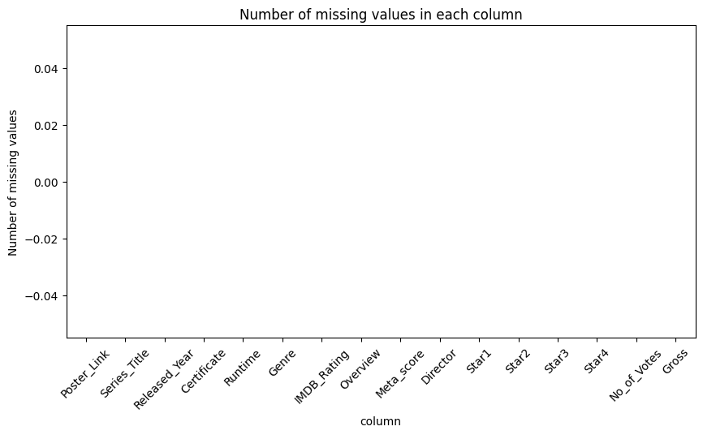

```python
import matplotlib.pyplot as plt

missing = df_imdb.isnull().sum()
plt.figure(figsize=(10, 5))
missing.plot(kind='bar', color='red')
plt.title("Number of missing values in each column")
plt.xlabel("column")
plt.ylabel("Number of missing values")
plt.xticks(rotation=45)
plt.show()
```

Justification: I used dropna() to clean the data of missing values to ensure an accurate and unbiased analysis. My decision to approach this approach was in line with the project's ultimate goal: to analyze the relationship between ratings and revenue.

### **Quality Issue 2:**

```python
# Convert 'Released_Year' to integer
df_imdb['Released_Year'] = pd.to_numeric(df_imdb['Released_Year'], errors='coerce')

# Convert 'Runtime' to numeric after cleaning
df_imdb['Runtime'] = pd.to_numeric(df_imdb['Runtime'], errors='coerce')

# Convert 'Meta_score' to numeric
df_imdb['Meta_score'] = pd.to_numeric(df_imdb['Meta_score'], errors='coerce')

# Convert 'Gross' to numeric after cleaning
df_imdb['Gross'] = pd.to_numeric(df_imdb['Gross'], errors='coerce')

# Convert 'Certificate' and 'Genre' to categorical (or leave as object if needed)
df_imdb['Certificate'] = df_imdb['Certificate'].astype('category')
df_imdb['Genre'] = df_imdb['Genre'].astype('category')
```

```python
df_imdb.info()
```

```
<class 'pandas.core.frame.DataFrame'>
Index: 1830 entries, 0 to 2535
Data columns (total 16 columns):
 #   Column         Non-Null Count  Dtype
---  ------         --------------  -----
 0   Poster_Link    1830 non-null   object
 1   Series_Title   1830 non-null   object
 2   Released_Year  1827 non-null   float64
 3   Certificate    1830 non-null   category
 4   Runtime        1830 non-null   int64
 5   Genre          1830 non-null   category
 6   IMDB_Rating    1830 non-null   float64
 7   Overview       1830 non-null   object
 8   Meta_score     1830 non-null   float64
 9   Director       1830 non-null   object
 10  Star1          1830 non-null   object
 11  Star2          1830 non-null   object
 12  Star3          1830 non-null   object
 13  Star4          1830 non-null   object
 14  No_of_Votes    1830 non-null   int64
 15  Gross          1830 non-null   float64
dtypes: category(2), float64(4), int64(2), object(8)
memory usage: 219.1+ KB
```

Justification: *Here the problem of different data types was transformed, as the type of each column was changed according to the data it contains. This step was taken to facilitate dealing with numeric values when analyzing and the ability to find calculations on them.*

```python
# Convert cleaned columns to appropriate numeric data types
data['Worldwide'] = pd.to_numeric(data['Worldwide'], errors='coerce')
data['Domestic'] = pd.to_numeric(data['Domestic'], errors='coerce')
data['Foreign'] = pd.to_numeric(data['Foreign'], errors='coerce')
data['Domestic_percent'] = pd.to_numeric(data['Domestic_percent'], errors='coerce')
data['Foreign_percent'] = pd.to_numeric(data['Foreign_percent'], errors='coerce')
```

```python
data.info()
```

```
<class 'pandas.core.frame.DataFrame'>
RangeIndex: 2600 entries, 0 to 2599
Data columns (total 6 columns):
 #   Column            Non-Null Count  Dtype
---  ------            --------------  -----
 0   Title             2600 non-null   object
 1   Worldwide         2600 non-null   int64
 2   Domestic          1839 non-null   float64
 3   Domestic_percent  1794 non-null   float64
 4   Foreign           2585 non-null   float64
 5   Foreign_percent   2582 non-null   float64
dtypes: float64(4), int64(1), object(1)
memory usage: 122.0+ KB
```

Here also in the second dataset the problem of the difference in data type was transformed, as the type of each column was changed according to the data it contains. This step was taken to facilitate dealing with numeric values when analyzing and the ability to find calculations on them.

To combine the dataset, the common column heading will be unified.

```python
df_imdb.rename(columns={'Series_Title': 'Title'}, inplace=True)
df_imdb.info()
```

```
<class 'pandas.core.frame.DataFrame'>
Index: 1830 entries, 0 to 2535
Data columns (total 16 columns):
 #   Column         Non-Null Count  Dtype
---  ------         --------------  -----
 0   Poster_Link    1830 non-null   object
 1   Title          1830 non-null   object
 2   Released_Year  1827 non-null   float64
 3   Certificate    1830 non-null   category
 4   Runtime        1830 non-null   int64
 5   Genre          1830 non-null   category
 6   IMDB_Rating    1830 non-null   float64
 7   Overview       1830 non-null   object
 8   Meta_score     1830 non-null   float64
 9   Director       1830 non-null   object
 10  Star1          1830 non-null   object
 11  Star2          1830 non-null   object
 12  Star3          1830 non-null   object
 13  Star4          1830 non-null   object
 14  No_of_Votes    1830 non-null   int64
 15  Gross          1830 non-null   float64
dtypes: category(2), float64(4), int64(2), object(8)
memory usage: 219.1+ KB
```

### **Remove unnecessary variables and combine datasets**

```python
df_imdb = df_imdb[['Title', 'Released_Year', 'Runtime', 'Genre', 'IMDB_Rating', 'Meta_score', 'No_of_Votes']]
data = data[['Title', 'Worldwide', 'Domestic', 'Foreign']]
```

```python
df_imdb.info()
```

```
<class 'pandas.core.frame.DataFrame'>
Index: 1830 entries, 0 to 2535
Data columns (total 7 columns):
 #   Column         Non-Null Count  Dtype
---  ------         --------------  -----
 0   Title          1830 non-null   object
 1   Released_Year  1827 non-null   float64
 2   Runtime        1830 non-null   int64
 3   Genre          1830 non-null   category
 4   IMDB_Rating    1830 non-null   float64
 5   Meta_score     1830 non-null   float64
 6   No_of_Votes    1830 non-null   int64
dtypes: category(1), float64(3), int64(2), object(1)
memory usage: 102.6+ KB
```

```python
data.info()
```

```
<class 'pandas.core.frame.DataFrame'>
RangeIndex: 2600 entries, 0 to 2599
Data columns (total 4 columns):
 #   Column     Non-Null Count  Dtype
---  ------     --------------  -----
 0   Title      2600 non-null   object
 1   Worldwide  2600 non-null   int64
 2   Domestic   1839 non-null   float64
 3   Foreign    2585 non-null   float64
dtypes: float64(2), int64(1), object(1)
memory usage: 81.4+ KB
```

Merge data set based on common Title column

```python
merged_df = pd.merge(df_imdb, data, on='Title', how='inner')
```

## 4. Update data store

```python
# Save cleaned datasets
df_imdb.to_csv('cleaned_data_imdb.csv', index=False)
data.to_csv('cleaned_data_box_office.csv', index=False)

# Save merged dataset
merged_df.to_csv('merged_data_movies.csv', index=False)
```

## 5. Answer the research question

### **5.1:** Define and answer the research question

*Research question:What is the relationship between a movie’s IMDB rating and its worldwide box office revenue?*

Visualization 1: Scatter Plot of IMDB Rating vs. Worldwide Revenue

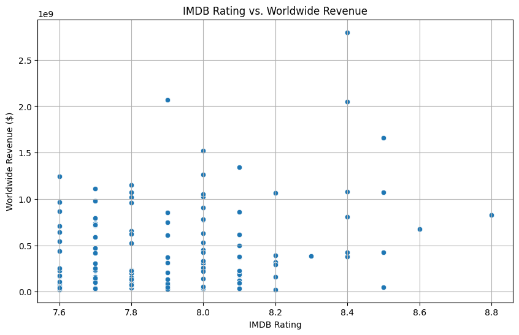

```python
import matplotlib.pyplot as plt
import seaborn as sns

plt.figure(figsize=(10,6))
sns.scatterplot(data=merged_df, x='IMDB_Rating', y='Worldwide')
plt.title('IMDB Rating vs. Worldwide Revenue')
plt.xlabel('IMDB Rating')
plt.ylabel('Worldwide Revenue ($)')
plt.grid(True)
plt.show()
```

We note from the results that there is a slight correlation, meaning that the higher the film's rating, the higher the revenues in general. However, the relationship is not strong and does not apply to all cases. We find that some films with average ratings (between 7.5 and 8) achieved very high revenues, indicating the presence of other factors affecting this relationship. On the other hand, some films with high ratings (above 8.5) did not achieve the highest revenues.

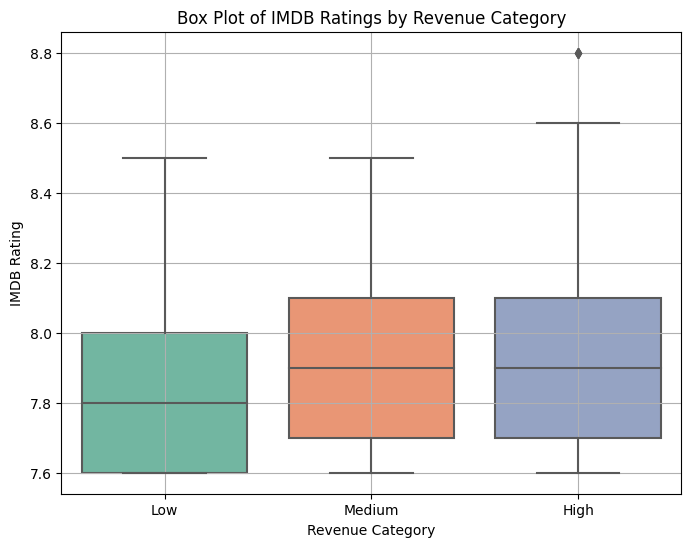

```python
import pandas as pd
import matplotlib.pyplot as plt
import seaborn as sns

# Categorize movies into 3 revenue groups: Low, Medium, High based on Worldwide revenue
merged_df['Revenue_Category'] = pd.qcut(merged_df['Worldwide'], q=3, labels=['Low', 'Medium', 'High'])

# Create a box plot to show the distribution of IMDB Ratings by Revenue Category
plt.figure(figsize=(8, 6))
sns.boxplot(x='Revenue_Category', y='IMDB_Rating', data=merged_df, palette='Set2')

plt.title('Box Plot of IMDB Ratings by Revenue Category')  # Title of the plot
plt.xlabel('Revenue Category')  # Label for x-axis
plt.ylabel('IMDB Rating')       # Label for y-axis
plt.grid(True)                  # Show grid for better readability
plt.show()
```

After dividing the films into three categories based on revenue: low, medium, and high, we can see the distribution of IMDB ratings within each category. We can conclude that the median values across the three categories are close, indicating that film ratings do not vary significantly based on revenue. Furthermore, the highest rating in the high-revenue category reached 8.8, the highest of all categories. Given that the distribution of ratings across the three categories is close, we can conclude that revenues do not depend solely on IMDB ratings.

### **5.2:** Reflection

Perhaps if I had more time to work on this project, I would have worked on improving data quality even further, for example, by processing missing data in a more in-depth and better way. I would also have analyzed additional variables such as film genre, director, and release year to determine their impact on IMDB ratings and revenues.